# Aplicación 1.2: Exploración de datos

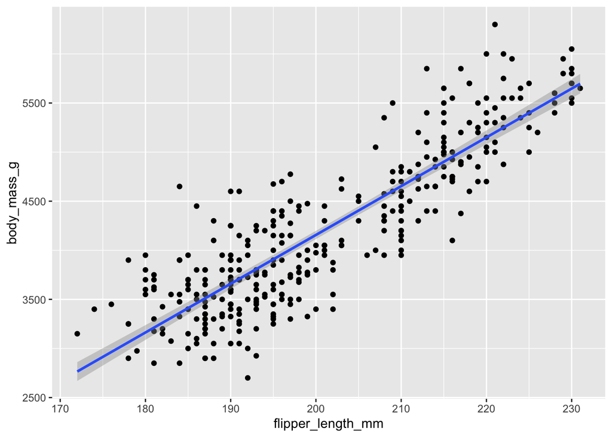

```r
df %>%
  ggplot(aes(x = flipper_length_mm, y = body_mass_g)) +
  geom_point() +
  geom_smooth(method = "lm")
```

Diferenciado por sexo

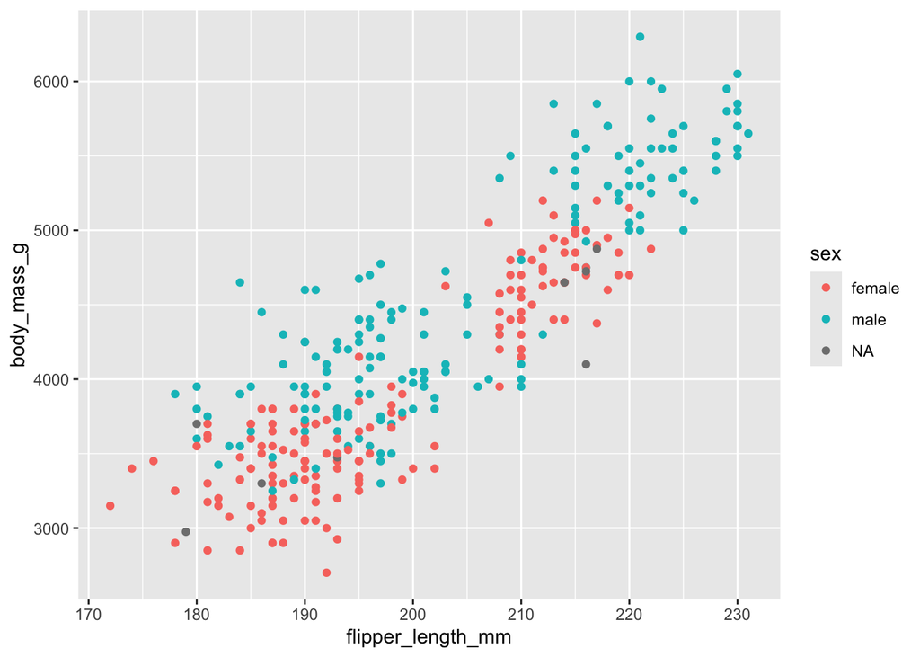

```r
df %>%
  ggplot(aes(x = flipper_length_mm, y = body_mass_g,
             color = sex)) +
  geom_point()
```

con línea de regresión añadida

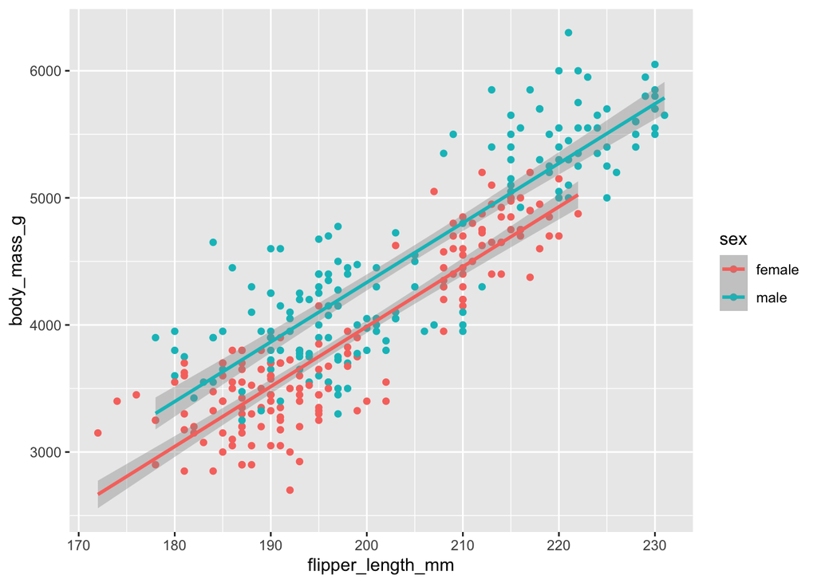

```r
df %>%
  filter(!is.na(sex)) %>%
  ggplot(aes(x = flipper_length_mm, y = body_mass_g,
             color = sex)) +
  geom_point() +
  geom_smooth(method = "lm")
```

Variación de la masa corporal media a lo largo de los años por especie

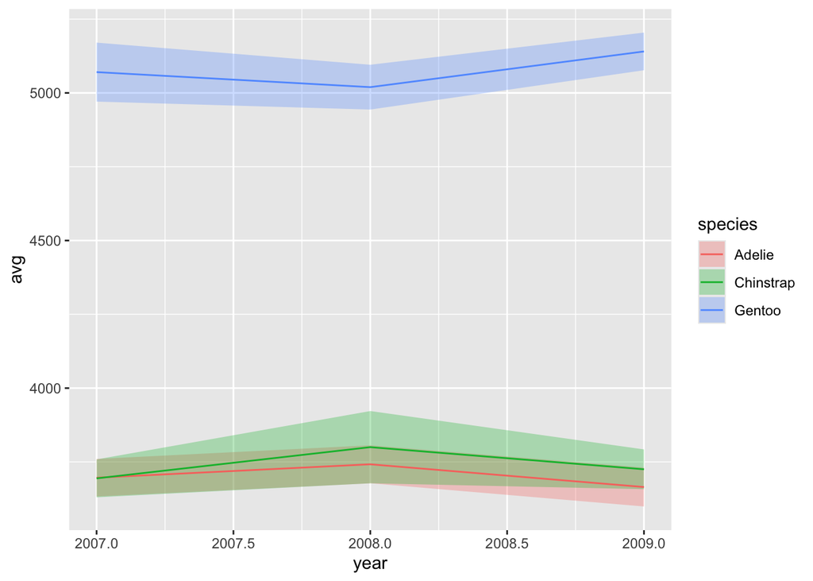

```r
df %>%
  group_by(species, year) %>%
  summarize(N = n(),
            avg = mean(body_mass_g, na.rm = TRUE),
            SE = sd(body_mass_g, na.rm = TRUE) / sqrt(N),
            .groups = "drop") %>%
  ggplot(aes(x = year, y = avg)) +
  geom_ribbon(aes(ymin = avg - SE, ymax = avg + SE,
                  fill = species),
              alpha = 0.3) +
  geom_line(aes(color = species))
```

## Agrupación - resumen

Media y desviación estándar de la longitud del pico para cada especie

```r
df %>%
  group_by(species) %>%
  summarize(avg_bill_length = mean(bill_length_mm, na.rm = TRUE),
            sd_bill_length = sd(bill_length_mm, na.rm = TRUE))
```

```
# A tibble: 3 × 3
  species   avg_bill_length sd_bill_length
  <fct>               <dbl>          <dbl>
1 Adelie               38.8           2.66
2 Chinstrap            48.8           3.34
3 Gentoo               47.5           3.08
```

Media y desviación estándar de la longitud del pico de cada especie por sexo

```r
df %>%
  filter(!is.na(sex)) %>%
  group_by(species, sex) %>%
  summarize(avg_bill_length = mean(bill_length_mm, na.rm = TRUE),
            sd_bill_length = sd(bill_length_mm, na.rm = TRUE))
```

```
# A tibble: 6 × 4
# Groups:   species [3]
  species   sex    avg_bill_length sd_bill_length
  <fct>     <fct>            <dbl>          <dbl>
1 Adelie    female            37.3           2.03
2 Adelie    male              40.4           2.28
3 Chinstrap female            46.6           3.11
4 Chinstrap male              51.1           1.56
5 Gentoo    female            45.6           2.05
6 Gentoo    male              49.5           2.72
```

## Agrupación - cálculo

Añadir una nueva columna al fichero de datos que muestre la longitud media de las aletas agrupadas por especies

```r
df <- df %>%
  group_by(species) %>%
  mutate(mean_flipper_length = mean(flipper_length_mm, na.rm = TRUE))

df %>%
  head()
```

```
# A tibble: 6 × 9
# Groups:   species [1]
  species island    bill_length_mm bill_depth_mm flipper_length_mm body_mass_g
  <fct>   <fct>              <dbl>         <dbl>             <int>       <int>
1 Adelie  Torgersen           39.1          18.7               181        3750
2 Adelie  Torgersen           39.5          17.4               186        3800
3 Adelie  Torgersen           40.3          18                 195        3250
4 Adelie  Torgersen           NA            NA                  NA          NA
5 Adelie  Torgersen           36.7          19.3               193        3450
6 Adelie  Torgersen           39.3          20.6               190        3650
# ℹ 3 more variables: sex <fct>, year <int>, mean_flipper_length <dbl>
```

Puntuación estandarizada (z-score) por especie para la longitud de las aletas

```r
df <- df %>%
  group_by(species) %>%
  mutate(flipper_z = (flipper_length_mm - mean(flipper_length_mm, na.rm = TRUE)) / sd(flipper_length_mm, na.rm = TRUE))
df %>%
  head()
```

```
# A tibble: 6 × 10
# Groups:   species [1]
  species island    bill_length_mm bill_depth_mm flipper_length_mm body_mass_g
  <fct>   <fct>              <dbl>         <dbl>             <int>       <int>
1 Adelie  Torgersen           39.1          18.7               181        3750
2 Adelie  Torgersen           39.5          17.4               186        3800
3 Adelie  Torgersen           40.3          18                 195        3250
4 Adelie  Torgersen           NA            NA                  NA          NA
5 Adelie  Torgersen           36.7          19.3               193        3450
6 Adelie  Torgersen           39.3          20.6               190        3650
# ℹ 4 more variables: sex <fct>, year <int>, mean_flipper_length <dbl>,
#   flipper_z <dbl>
```

Añadir una columna para la media y la desviación estándar por especie para la longitud del pico

```r
df <- df %>%
  group_by(species) %>%
  mutate(mean_val = mean(bill_length_mm, na.rm = TRUE),
         sd_val = sd(bill_length_mm, na.rm = TRUE))
df %>%
  head()
```

```
# A tibble: 6 × 12
# Groups:   species [1]
  species island    bill_length_mm bill_depth_mm flipper_length_mm body_mass_g
  <fct>   <fct>              <dbl>         <dbl>             <int>       <int>
1 Adelie  Torgersen           39.1          18.7               181        3750
2 Adelie  Torgersen           39.5          17.4               186        3800
3 Adelie  Torgersen           40.3          18                 195        3250
4 Adelie  Torgersen           NA            NA                  NA          NA
5 Adelie  Torgersen           36.7          19.3               193        3450
6 Adelie  Torgersen           39.3          20.6               190        3650
# ℹ 6 more variables: sex <fct>, year <int>, mean_flipper_length <dbl>,
#   flipper_z <dbl>, mean_val <dbl>, sd_val <dbl>
```

**Código Python**

## Lectura de librerías

```python
import numpy as np
import pandas as pd
import matplotlib.pyplot as plt
import seaborn as sns
# Datos de la aplicación: base datos palmerpenguins
# (https://github.com/mcnakhaee/palmerpenguins)
from palmerpenguins import load_penguins
```

## Lectura de datos

```python
df = load_penguins()
df.head()
```

```
  species     island  bill_length_mm  ...  body_mass_g     sex  year
0  Adelie  Torgersen            39.1  ...       3750.0    male  2007
1  Adelie  Torgersen            39.5  ...       3800.0  female  2007
2  Adelie  Torgersen            40.3  ...       3250.0  female  2007
3  Adelie  Torgersen             NaN  ...          NaN     NaN  2007
4  Adelie  Torgersen            36.7  ...       3450.0  female  2007

[5 rows x 8 columns]
```

## Análisis exploratorio

Recuento de los NAs en cada columna

```python
df.isnull().any()
```

```
species              False
island               False
bill_length_mm        True
bill_depth_mm         True
flipper_length_mm     True
body_mass_g           True
sex                   True
year                 False
dtype: bool
```

```python
len(df) - df.count()
```

```
species               0
island                0
bill_length_mm        2
bill_depth_mm         2
flipper_length_mm     2
body_mass_g           2
sex                  11
year                  0
dtype: int64
```

Para eliminar todas las filas con un NA habría que ejecutar el siguiente código

```python
# df = df.dropna()
```

Número de especies

```python
df['species'].value_counts()
```

```
species
Adelie       152
Gentoo       124
Chinstrap     68
Name: count, dtype: int64
```

Número de islas

```python
df['island'].value_counts()
```

```
island
Biscoe       168
Dream        124
Torgersen     52
Name: count, dtype: int64
```

Número de especies en cada isla

```python
df[['species', 'island']].value_counts()
```

```
species    island
Gentoo     Biscoe       124
Chinstrap  Dream         68
Adelie     Dream         56
           Torgersen     52
           Biscoe        44
Name: count, dtype: int64
```

Tabla 3x3 de recuento de especies por isla

```python
pd.crosstab(df['species'], df['island'])
```

```
island     Biscoe  Dream  Torgersen
species
Adelie         44     56         52
Chinstrap       0     68          0
Gentoo        124      0          0
```

Tabla 3x3 de proporciones de especies por isla

```python
pd.crosstab(df['species'], df['island']) / len(df)
```

```
island       Biscoe     Dream  Torgersen
species
Adelie     0.127907  0.162791   0.151163
Chinstrap  0.000000  0.197674   0.000000
Gentoo     0.360465  0.000000   0.000000
```

Gráfico de barras de especies

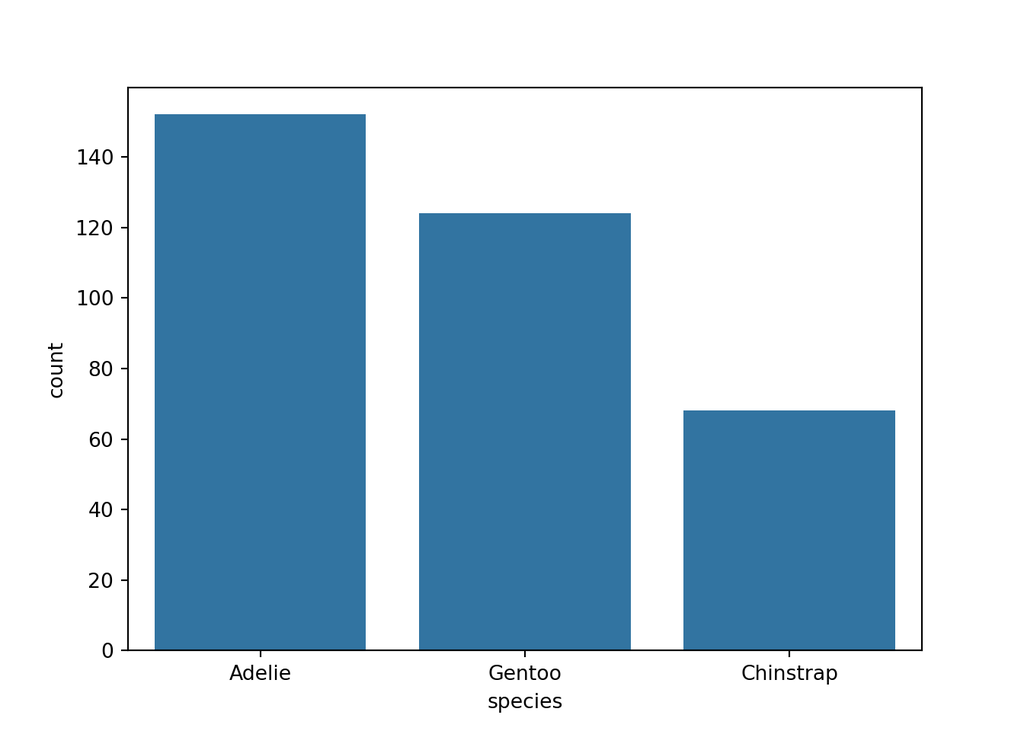

```python
sns.countplot(x = 'species', data = df);
plt.show()
```

Descripción de todas la columnas de la base de datos

```python
df.describe()
```

```
       bill_length_mm  bill_depth_mm  ...  body_mass_g         year
count      342.000000     342.000000  ...   342.000000   344.000000
mean        43.921930      17.151170  ...  4201.754386  2008.029070
std          5.459584       1.974793  ...   801.954536     0.818356
min         32.100000      13.100000  ...  2700.000000  2007.000000
25%         39.225000      15.600000  ...  3550.000000  2007.000000
50%         44.450000      17.300000  ...  4050.000000  2008.000000
75%         48.500000      18.700000  ...  4750.000000  2009.000000
max         59.600000      21.500000  ...  6300.000000  2009.000000

[8 rows x 5 columns]
```

Cálculo de la media de la longitud y la profundidad del pico

```python
df[['bill_length_mm', 'bill_depth_mm']].mean()
```

```
bill_length_mm    43.92193
bill_depth_mm     17.15117
dtype: float64
```

Cálculo de los cuantiles 25, 50 y 75 para la longitud y profundidad del pico en la Isla Biscoe

```python
df.loc[df['island'] == 'Biscoe', ['bill_length_mm', 'bill_depth_mm']].quantile([0.25, 0.5, 0.75])
```

```
      bill_length_mm  bill_depth_mm
0.25            42.0           14.5
0.50            45.8           15.5
0.75            48.7           17.0
```

Boxplot vertical de la longitud del pico por especie

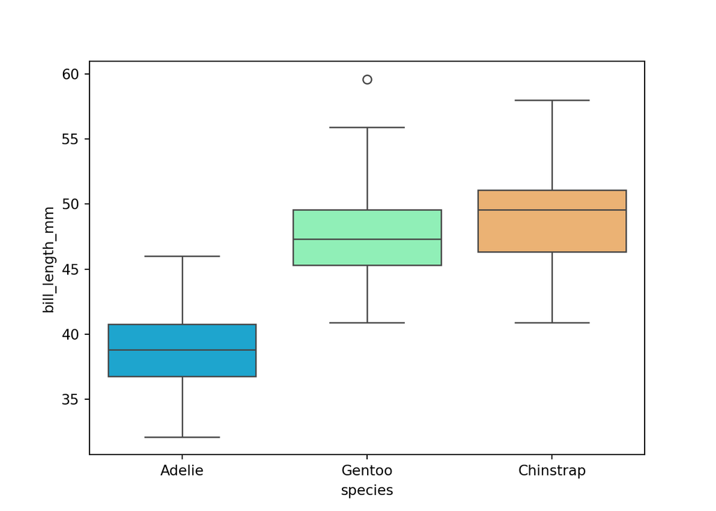

```python
sns.boxplot(x = 'species', y = 'bill_length_mm', data = df, orient = 'v', palette = 'rainbow');
plt.show()
```

Boxplot horizontal

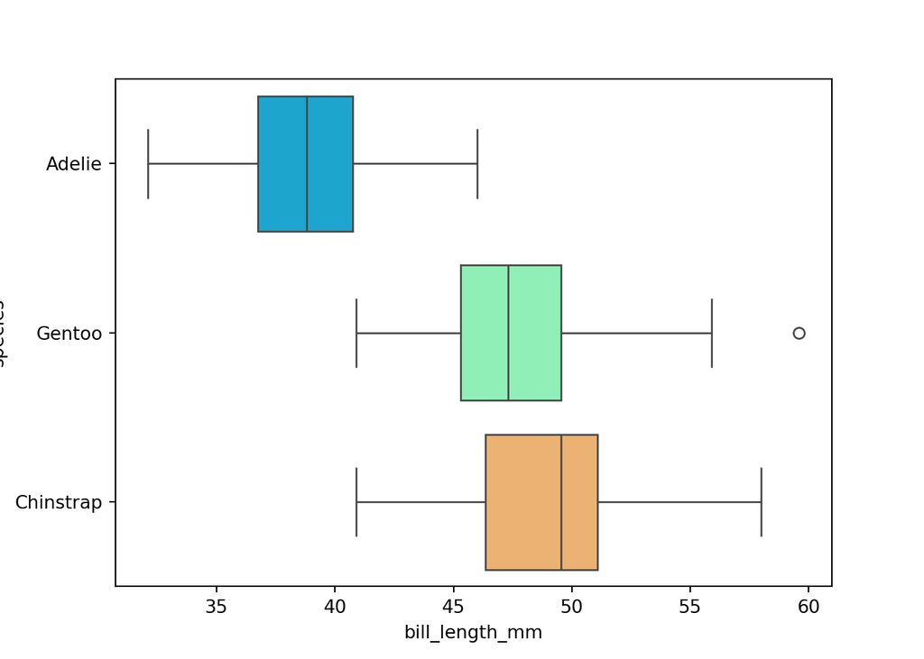

```python
sns.boxplot(x = 'bill_length_mm', y = 'species', data = df, orient = 'h', palette = 'rainbow');
plt.show()
```

Densidad estimada de la longitud del pico agrupada por sexo

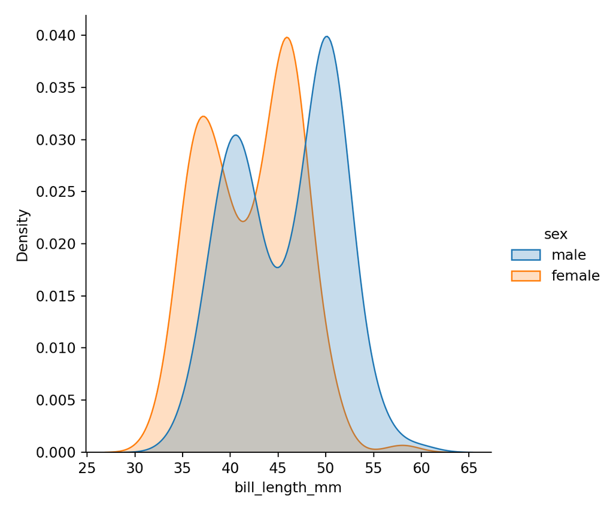

```python
sns.displot(x = 'bill_length_mm',
            data = df,
            kind = 'kde',
            hue = 'sex',
            fill = True);
plt.show()
```

con facetas por especie

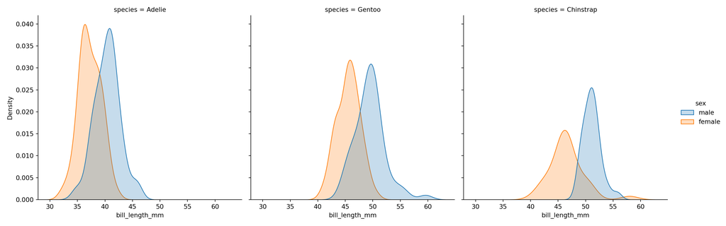

```python
sns.displot(x = 'bill_length_mm',
            data = df,
            kind = 'kde',
            hue = 'sex',
            col = 'species',
            fill = True);
plt.show()
```

Diagrama de dispersión de la masa corporal en relación con la longitud de las aletas

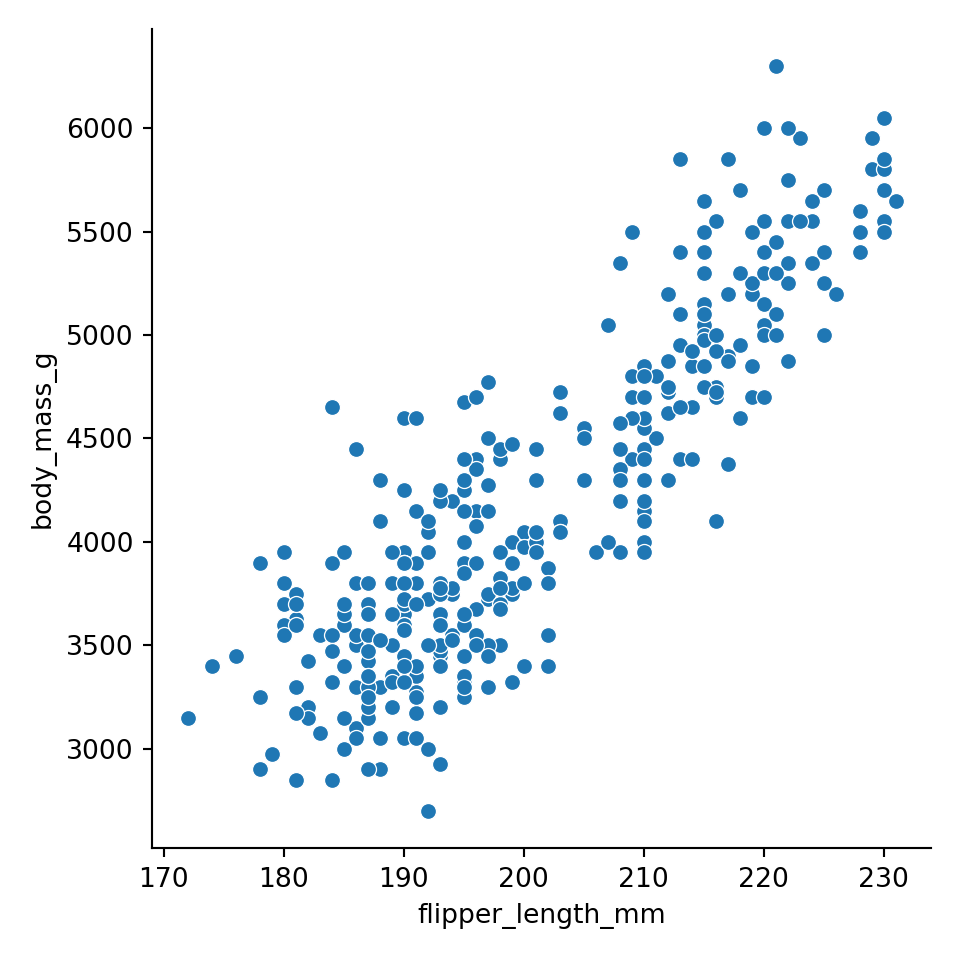

```python
sns.relplot(x = 'flipper_length_mm', y = 'body_mass_g', data = df);
plt.show()
```

con línea de regresión añadida

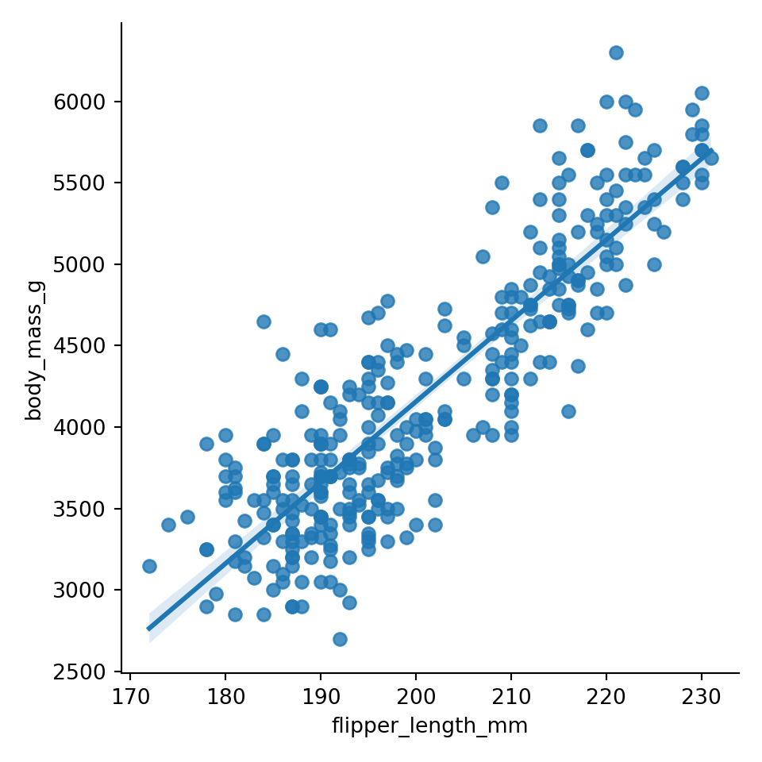

```python
sns.lmplot(x = 'flipper_length_mm', y = 'body_mass_g', data = df);
plt.show()
```

Diferenciado por sexo

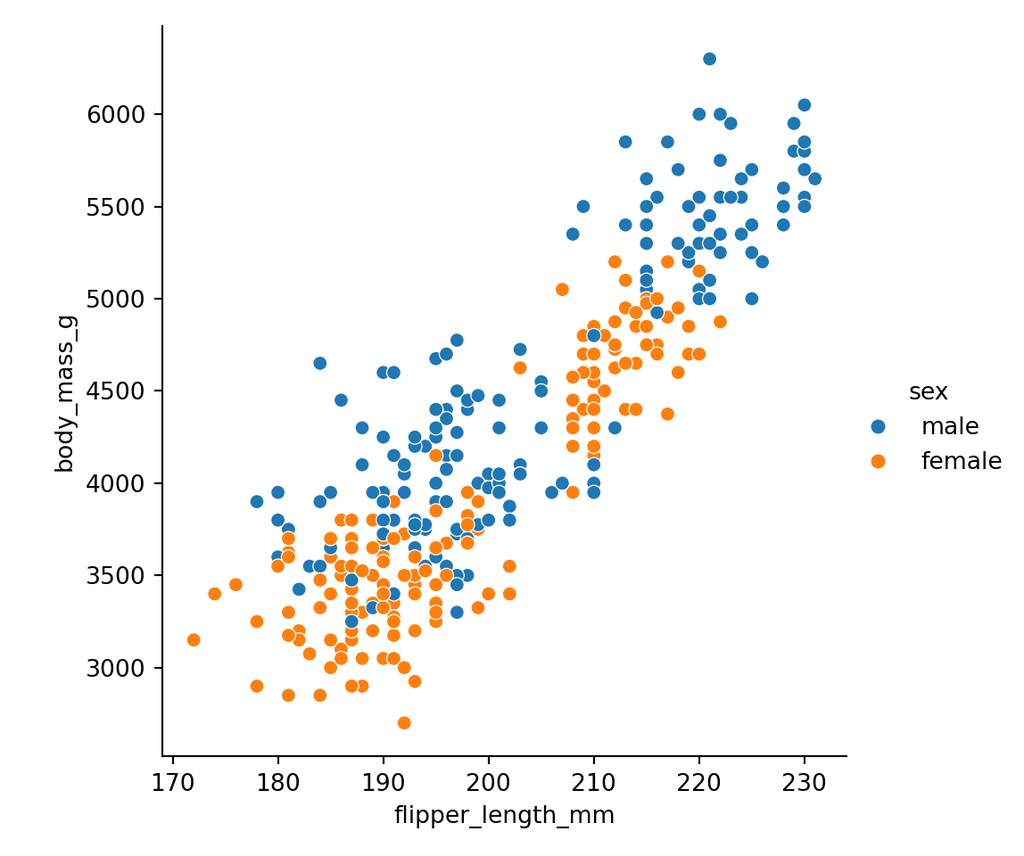

```python
sns.relplot(x = 'flipper_length_mm', y = 'body_mass_g', data = df, hue = 'sex');
plt.show()
```

y con línea de regresión añadida

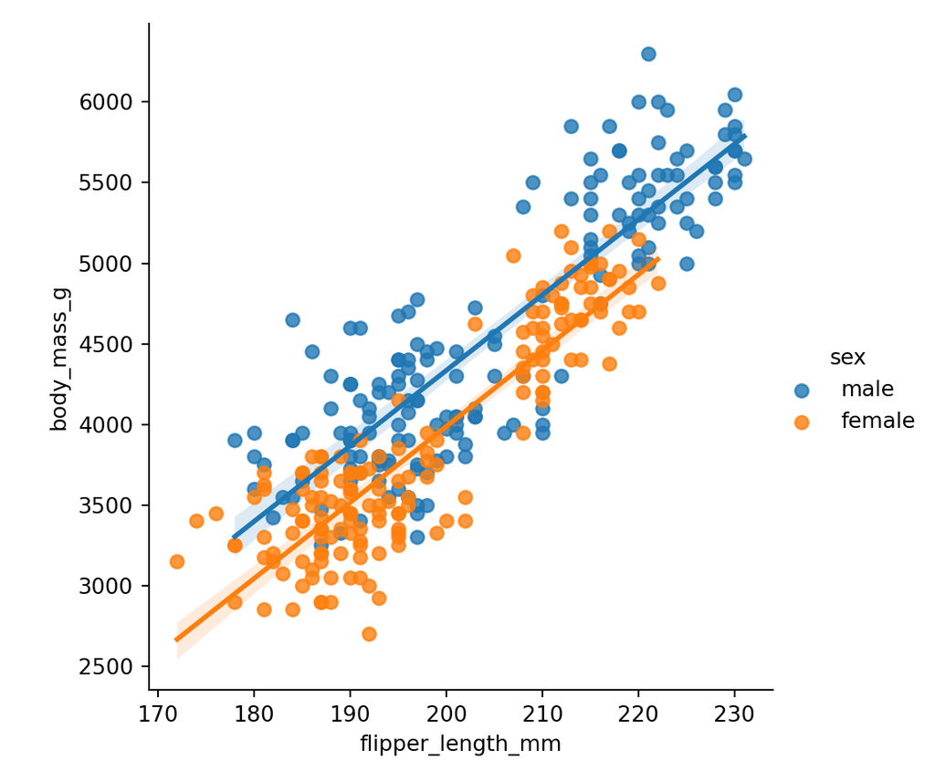

```python
sns.lmplot(x = 'flipper_length_mm', y = 'body_mass_g', data = df, hue = 'sex');
plt.show()
```

Variación de la masa corporal media a lo largo de los años por especie

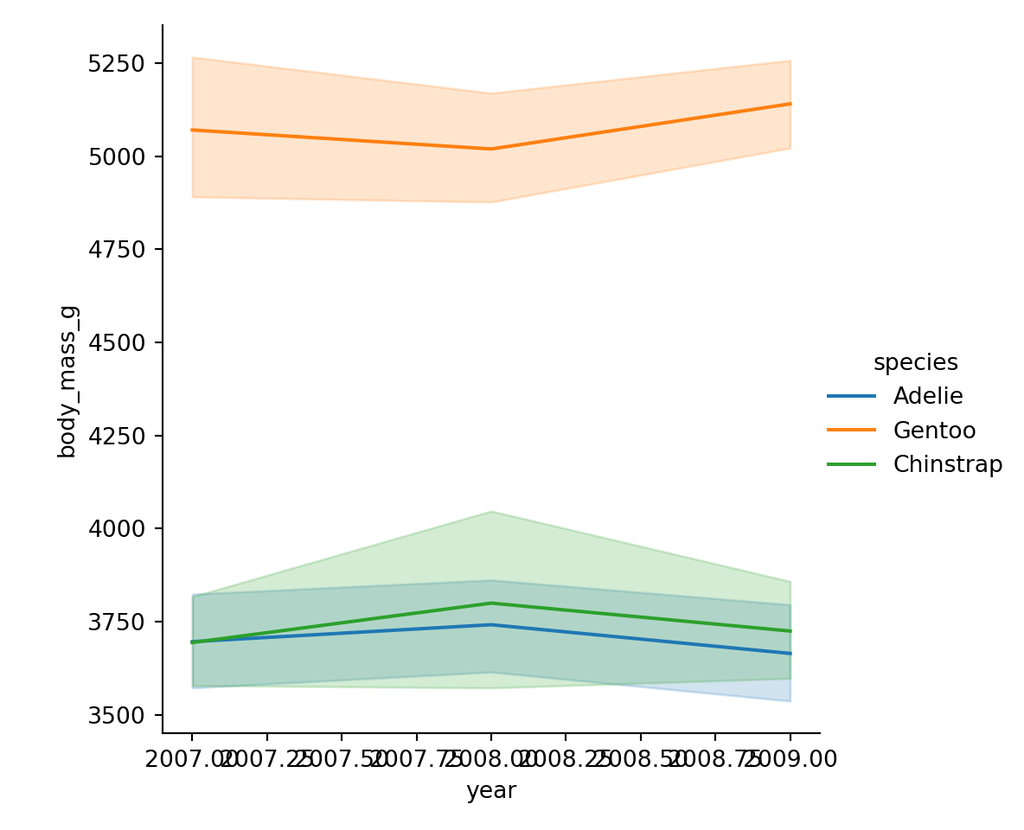

```python
sns.relplot(x = 'year', y = 'body_mass_g', kind = 'line',
           hue = 'species', data = df);
plt.show()
```

## Agrupación - resumen

Media y desviación estándar de la longitud del pico para cada especie

```python
species_bill_length = (df
           .groupby('species')
           .agg(avg_bill_length = ('bill_length_mm', 'mean'),
               sd_bill_length = ('bill_length_mm', 'std')).round(1)
           .reset_index())
species_bill_length
```

```
     species  avg_bill_length  sd_bill_length
0     Adelie             38.8             2.7
1  Chinstrap             48.8             3.3
2     Gentoo             47.5             3.1
```

Media y desviación estándar de la longitud del pico de cada especie por sexo

```python
species_bill_length_sex = (df
           .groupby(['species', 'sex'])
           .agg(avg_bill_length = ('bill_length_mm', 'mean'),
               sd_bill_length = ('bill_length_mm', 'std')).round(1)
           .reset_index())
species_bill_length_sex
```

```
     species     sex  avg_bill_length  sd_bill_length
0     Adelie  female             37.3             2.0
1     Adelie    male             40.4             2.3
2  Chinstrap  female             46.6             3.1
3  Chinstrap    male             51.1             1.6
4     Gentoo  female             45.6             2.1
5     Gentoo    male             49.5             2.7
```

## Agrupación - cálculo

Añadir una nueva columna al fichero de datos que muestre la longitud media de las aletas agrupadas por especies

```python
df['mean_flipper_length'] = df.groupby('species')['flipper_length_mm'].transform('mean')
df.head()
```

```
  species     island  bill_length_mm  ...     sex  year  mean_flipper_length
0  Adelie  Torgersen            39.1  ...    male  2007           189.953642
1  Adelie  Torgersen            39.5  ...  female  2007           189.953642
2  Adelie  Torgersen            40.3  ...  female  2007           189.953642
3  Adelie  Torgersen             NaN  ...     NaN  2007           189.953642
4  Adelie  Torgersen            36.7  ...  female  2007           189.953642

[5 rows x 9 columns]
```

Puntuación estandarizada (z-score) por especie para la longitud de las aletas

```python
df['flipper_z'] = df.groupby('species')['flipper_length_mm'].transform(lambda x: (x - x.mean()) / x.std()).round(2)
df.head()
```

```
  species     island  bill_length_mm  ...  year  mean_flipper_length  flipper_z
0  Adelie  Torgersen            39.1  ...  2007           189.953642      -1.37
1  Adelie  Torgersen            39.5  ...  2007           189.953642      -0.60
2  Adelie  Torgersen            40.3  ...  2007           189.953642       0.77
3  Adelie  Torgersen             NaN  ...  2007           189.953642        NaN
4  Adelie  Torgersen            36.7  ...  2007           189.953642       0.47

[5 rows x 10 columns]
```

Añadir una columna para la media y la desviación estándar por especie para la longitud del pico

```python
df = df.assign(
    mean_val = df.groupby(["species"]).bill_length_mm.transform('mean'),
    sd_val = df.groupby(["species"]).bill_length_mm.transform('std'))
df.head()
```

```
  species     island  bill_length_mm  ...  flipper_z   mean_val    sd_val
0  Adelie  Torgersen            39.1  ...      -1.37  38.791391  2.663405
1  Adelie  Torgersen            39.5  ...      -0.60  38.791391  2.663405
2  Adelie  Torgersen            40.3  ...       0.77  38.791391  2.663405
3  Adelie  Torgersen             NaN  ...        NaN  38.791391  2.663405
4  Adelie  Torgersen            36.7  ...       0.47  38.791391  2.663405

[5 rows x 12 columns]
```